# Preliminary Expanded Feature Clustering Sensitivity

Sam A. Sievertsen

2026-09-04

## Purpose

| Config | Question it answers |
| --- | --- |
| `anchor` | Published 17 features, refit on common rows. Validity check. |
| `bas2_fhx` | **BASE.** BAS RR (v01) + Drive, plus FHx psychosis and hospitalization |
| `bas4_fhx` | Does adding BIS (v01) and Fun Seeking change anything? |
| `cbcl3_dim` | Does swapping DSM-5 depression + anxiety for the Anxious/Depressed syndrome scale change anything? |
| `cbcl3_bin` | Does the classic binary dysregulation profile (all 3 scales T >= cutoff) change anything? |
| `cbcl_dp_rawsum` | **Does replacing the 4 CBCL scales with the DP raw sum (Giampetruzzi et al., 2026) change anything?** |
| `cbcl_dp_pc1` | **Does replacing the 4 CBCL scales with the DP first principal component change anything?** |
| `ace_split` | Does partitioning abuse out of the ACE composite change anything? |
| `full_maximal` | Everything at once: all current features plus BIS, Fun Seeking, FHx additions, and the ACE abuse partition, holding CBCL as-is |
| `full_maximal_dpsum` | **Everything at once, but with the 4 CBCL scales replaced by the DP raw sum** |
| `anchor_nocbcl` | What remains of the published solution with the CBCL scales removed entirely? |
| `full_maximal_nocbcl` | What remains of the maximal solution with the CBCL scales removed entirely? |

The two new DP configurations follow Giampetruzzi et al. (2026, *JCPP*), who operationalized the dysregulation profile two ways: as the sum of the three raw subscale scores, and as the first principal component of the three subscales (centered and scaled). Both replace the four CBCL scales with a single continuous variable, which also isolates whether the `cbcl3_bin` collapse was due to dichotomization or to reducing four features to one. Note that Giampetruzzi used the youth self-report YSR; the CBCL here is parent report.

Read the **CBCL Dysregulation Profile Variables**, **Decision Aid**, and **Feature Separation Profiles** sections first. Everything else is supporting detail.

Existing cached solutions are reused. The DP variables are derived from the CBCL subscales already in the feature union, so the analytic row set should be unchanged; a fingerprint check halts execution if it is not.

Bootstrap replicates default to 25. Rerun the chosen configuration at `n_boot = 1000` before reporting anything externally.

## Data Prep

```
family_history_psychosis: 282 endorsed, 454 missing of 11860family_history_hospitalization: 1107 endorsed, 468 missing of 11860
```

```
abuse_physical: 95 endorsed (0.82%), 313 missingabuse_sexual: 96 endorsed (0.83%), 313 missingabuse_emotional: 5231 endorsed (44.12%), 3 missing
```

```
ACE reduced sum: range 0 to 7; 0 negative values (should be 0)
```

```
CBCL dysregulation profile (all 3 scales T >= 65): 132 endorsed (1.44%)
```

```
Rows with CBCL T-scores but missing a DP raw sum: 6 (should be 0)
```

```
SDSC total vs subscale sum: 9187 of 9187 exact matches (r = 1)
```

```
Rows retained: 9040 of 9193 (153 dropped on new feature missingness)
```

```
Row fingerprint matches cached solutions (n = 9040); cached fits will be reused
```

Feature composition by configuration

| config | n_features | n_numeric | n_categorical | varies_from_base |
| --- | --- | --- | --- | --- |
| anchor | 17 | 14 | 3 | Published 17 features (validity check) |
| bas2_fhx | 21 | 16 | 5 | BASE: + BAS RR & Drive, + FHx psychosis & hospitalization |
| bas4_fhx | 23 | 18 | 5 | BASE + BIS & BAS Fun Seeking |
| cbcl3_dim | 20 | 15 | 5 | BASE, DSM-5 dep+anx swapped for Anxious/Depressed syndrome |
| cbcl3_bin | 18 | 12 | 6 | BASE, 4 CBCL scales replaced by binary DP (all T >= 65) |
| cbcl_dp_rawsum | 18 | 13 | 5 | BASE, 4 CBCL scales replaced by DP raw sum (anxdep + attn + aggr) |
| cbcl_dp_pc1 | 18 | 13 | 5 | BASE, 4 CBCL scales replaced by DP PC1 (scaled PCA of 3 raw sums) |
| ace_split | 24 | 16 | 8 | BASE, ACE partitioned into 3 abuse binaries + reduced sum |
| full_maximal | 26 | 18 | 8 | All accepted additions combined, CBCL held as-is |
| full_maximal_dpsum | 23 | 15 | 8 | MAXIMAL, 4 CBCL scales replaced by DP raw sum |
| anchor_nocbcl | 13 | 10 | 3 | ANCHOR with all 4 CBCL scales REMOVED |
| full_maximal_nocbcl | 22 | 14 | 8 | MAXIMAL with all 4 CBCL scales REMOVED |

## CBCL Dysregulation Profile Variables

Descriptive characterization of the two continuous DP operationalizations from Giampetruzzi et al. (2026), computed on the analytic sample. The raw sum implicitly weights subscales by their item count (Anxious/Depressed 13 items, Attention Problems 10, Aggressive Behavior 18), whereas the scaled PCA weights them by their loadings.

PCA of the three CBCL DP raw subscale sums (centered, scaled): variance explained

| component | sd | variance_explained | cumulative |
| --- | --- | --- | --- |
| PC1 | 1.442 | 0.694 | 0.694 |
| PC2 | 0.739 | 0.182 | 0.875 |
| PC3 | 0.611 | 0.125 | 1.000 |

PCA loadings (Giampetruzzi et al. 2026 YSR-DP PC1 loadings at T1: anxdep 0.57, attn 0.57, aggr 0.59)

| subscale | PC1 | PC2 | PC3 |
| --- | --- | --- | --- |
| mh_p_cbcl__synd__anxdep_sum | 0.549 | -0.804 | -0.228 |
| mh_p_cbcl__synd__attn_sum | 0.579 | 0.563 | -0.590 |
| mh_p_cbcl__synd__aggr_sum | 0.603 | 0.193 | 0.774 |

Implicit relative weighting of each subscale under the raw sum vs PC1

| subscale | raw_sd | raw_sum_relative_weight | pc1_loading | pc1_relative_weight_on_raw_scale |
| --- | --- | --- | --- | --- |
| mh_p_cbcl__synd__anxdep_sum | 2.993 | 1.000 | 0.549 | 1.267 |
| mh_p_cbcl__synd__attn_sum | 3.404 | 1.137 | 0.579 | 1.174 |
| mh_p_cbcl__synd__aggr_sum | 4.161 | 1.390 | 0.603 | 1.000 |

Distributional descriptives: DP variables, raw subscale sums, and current T-scores (pct_at_min = floor rate)

| variable | n | mean | sd | median | mad | min | p25 | p75 | max | skew | kurtosis | pct_at_min |
| --- | --- | --- | --- | --- | --- | --- | --- | --- | --- | --- | --- | --- |
| cbcl_dp_raw_sum | 9040 | 8.382 | 8.840 | 6.000 | 7.413 | 0.00 | 2.00 | 12.000 | 66.000 | 1.803 | 4.088 | 11.947 |
| cbcl_dp_pc1 | 9040 | 0.000 | 1.442 | -0.434 | 1.131 | -1.38 | -1.04 | 0.563 | 9.368 | 1.777 | 3.963 | 11.947 |
| mh_p_cbcl__synd__anxdep_sum | 9040 | 2.437 | 2.993 | 1.000 | 1.483 | 0.00 | 0.00 | 4.000 | 26.000 | 1.993 | 5.402 | 31.449 |
| mh_p_cbcl__synd__attn_sum | 9040 | 2.843 | 3.404 | 2.000 | 2.965 | 0.00 | 0.00 | 4.000 | 19.000 | 1.493 | 2.036 | 33.938 |
| mh_p_cbcl__synd__aggr_sum | 9040 | 3.103 | 4.161 | 2.000 | 2.965 | 0.00 | 0.00 | 4.000 | 32.000 | 2.222 | 6.367 | 33.761 |
| mh_p_cbcl__dsm__dep_tscore | 9040 | 53.424 | 5.570 | 50.000 | 0.000 | 50.00 | 50.00 | 56.000 | 89.000 | 2.045 | 4.125 | 52.212 |
| mh_p_cbcl__dsm__anx_tscore | 9040 | 53.301 | 5.905 | 51.000 | 1.483 | 50.00 | 50.00 | 54.000 | 97.000 | 2.640 | 8.097 | 43.949 |
| mh_p_cbcl__synd__attn_tscore | 9040 | 53.668 | 5.922 | 51.000 | 1.483 | 50.00 | 50.00 | 55.000 | 97.000 | 2.515 | 7.860 | 41.261 |
| mh_p_cbcl__synd__aggr_tscore | 9040 | 52.627 | 5.249 | 50.000 | 0.000 | 50.00 | 50.00 | 52.000 | 94.000 | 2.849 | 9.654 | 60.066 |
| mh_p_cbcl__synd__anxdep_tscore | 9040 | 53.321 | 5.807 | 50.000 | 0.000 | 50.00 | 50.00 | 54.000 | 100.000 | 2.319 | 6.172 | 51.338 |

Pearson correlations among DP variables, raw subscales, and current CBCL T-scores

|  | cbcl_dp_raw_sum | cbcl_dp_pc1 | mh_p_cbcl__synd__anxdep_sum | mh_p_cbcl__synd__attn_sum | mh_p_cbcl__synd__aggr_sum | mh_p_cbcl__dsm__dep_tscore | mh_p_cbcl__dsm__anx_tscore | mh_p_cbcl__synd__attn_tscore | mh_p_cbcl__synd__aggr_tscore | mh_p_cbcl__synd__anxdep_tscore |
| --- | --- | --- | --- | --- | --- | --- | --- | --- | --- | --- |
| cbcl_dp_raw_sum | 1.000 | 0.999 | 0.771 | 0.832 | 0.889 | 0.729 | 0.717 | 0.812 | 0.858 | 0.755 |
| cbcl_dp_pc1 | 0.999 | 1.000 | 0.792 | 0.835 | 0.869 | 0.737 | 0.736 | 0.816 | 0.838 | 0.776 |
| mh_p_cbcl__synd__anxdep_sum | 0.771 | 0.792 | 1.000 | 0.465 | 0.539 | 0.706 | 0.891 | 0.467 | 0.518 | 0.973 |
| mh_p_cbcl__synd__attn_sum | 0.832 | 0.835 | 0.465 | 1.000 | 0.614 | 0.547 | 0.470 | 0.964 | 0.583 | 0.459 |
| mh_p_cbcl__synd__aggr_sum | 0.889 | 0.869 | 0.539 | 0.614 | 1.000 | 0.595 | 0.498 | 0.601 | 0.973 | 0.529 |
| mh_p_cbcl__dsm__dep_tscore | 0.729 | 0.737 | 0.706 | 0.547 | 0.595 | 1.000 | 0.624 | 0.549 | 0.582 | 0.707 |
| mh_p_cbcl__dsm__anx_tscore | 0.717 | 0.736 | 0.891 | 0.470 | 0.498 | 0.624 | 1.000 | 0.473 | 0.485 | 0.904 |
| mh_p_cbcl__synd__attn_tscore | 0.812 | 0.816 | 0.467 | 0.964 | 0.601 | 0.549 | 0.473 | 1.000 | 0.586 | 0.460 |
| mh_p_cbcl__synd__aggr_tscore | 0.858 | 0.838 | 0.518 | 0.583 | 0.973 | 0.582 | 0.485 | 0.586 | 1.000 | 0.516 |
| mh_p_cbcl__synd__anxdep_tscore | 0.755 | 0.776 | 0.973 | 0.459 | 0.529 | 0.707 | 0.904 | 0.460 | 0.516 | 1.000 |

```
Correlation between DP raw sum and DP PC1: 0.999
```

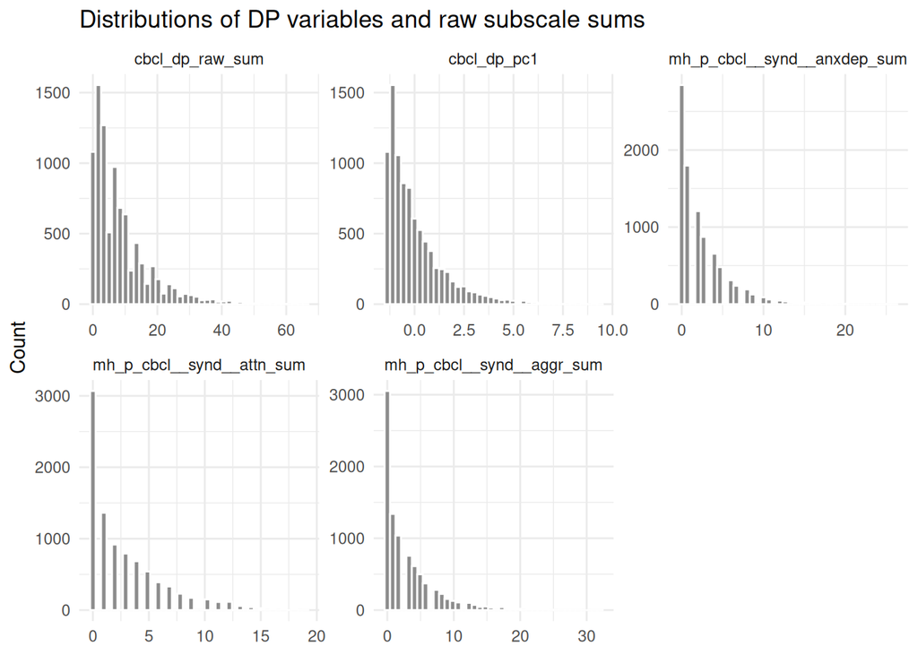

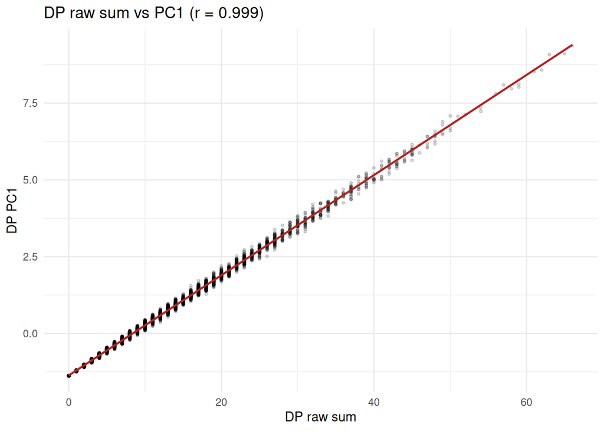

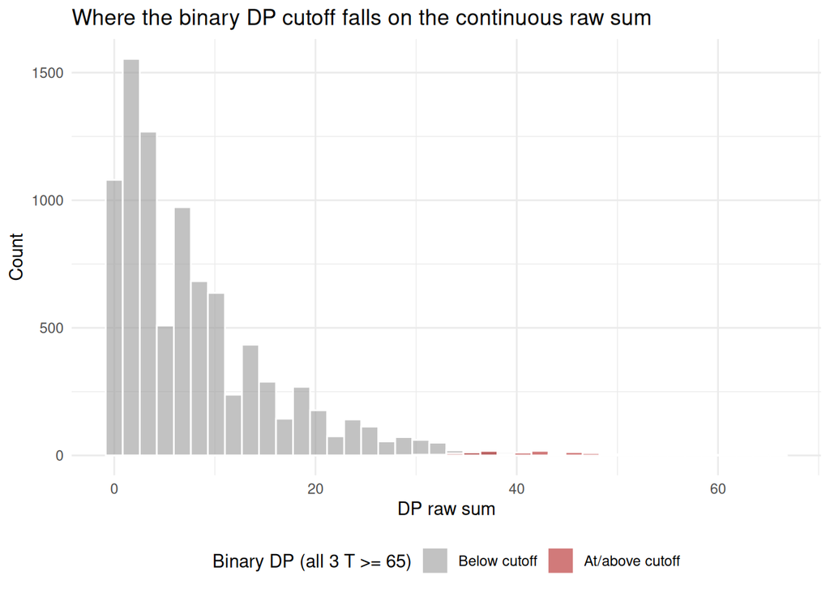

**Reading this section:**

- If PC1 explains roughly two thirds of variance or more with near-equal loadings, the three subscales behave as a single dimension, consistent with Giampetruzzi (67 to 77%, loadings 0.55 to 0.63) and Deutz’s bifactor general factor
- If the raw sum and PC1 correlate above roughly 0.97, they are functionally one variable for clustering purposes and the choice between them is presentational
- `pct_at_min` on the raw sum is the floor rate. A large floor in a population sample is expected and is the analogue of T-score truncation at 50
- The implicit weighting table shows how much more the raw sum leans on Aggressive Behavior than PC1 does

## Fit All Configurations

[output not shown]

```
Data-driven lambda by configuration:
```

```
             anchor            bas2_fhx            bas4_fhx           cbcl3_dim
              3.337               4.526               4.526               4.526
          cbcl3_bin      cbcl_dp_rawsum         cbcl_dp_pc1           ace_split
              5.300               4.526               4.526               4.923
       full_maximal  full_maximal_dpsum       anchor_nocbcl full_maximal_nocbcl
              4.923               4.923               3.337               4.923
```

Label alignment check: higher-risk cluster oriented by SDSC total

| config | mean_sds_higher | mean_sds_lower | n_higher |
| --- | --- | --- | --- |
| anchor | 46.24 | 34.51 | 1369 |
| bas2_fhx | 45.80 | 34.52 | 1416 |
| bas4_fhx | 45.71 | 34.51 | 1433 |
| cbcl3_dim | 44.50 | 34.49 | 1627 |
| cbcl3_bin | 38.94 | 34.76 | 3303 |
| cbcl_dp_rawsum | 42.66 | 34.38 | 2084 |
| cbcl_dp_pc1 | 42.66 | 34.38 | 2088 |
| ace_split | 43.93 | 34.26 | 1897 |
| full_maximal | 43.90 | 34.26 | 1904 |
| full_maximal_dpsum | 39.52 | 34.15 | 3604 |
| anchor_nocbcl | 42.24 | 34.51 | 2084 |
| full_maximal_nocbcl | 38.88 | 34.50 | 3697 |

## Internal Validation Across k

Gower silhouette is computed on the full analytic sample. The distance matrix depends only on the feature set, not on *k*, so it is computed once per configuration and reused across all candidate solutions.

```
full_maximal_dpsum: computing full-sample Gower silhouette
```

Gower silhouette by k (full sample, n = 9040, z_score scaling)

| k | anchor | bas2_fhx | bas4_fhx | cbcl3_dim | cbcl3_bin | cbcl_dp_rawsum | cbcl_dp_pc1 | ace_split | full_maximal | full_maximal_dpsum | anchor_nocbcl | full_maximal_nocbcl |
| --- | --- | --- | --- | --- | --- | --- | --- | --- | --- | --- | --- | --- |
| 2 | 0.319 | 0.299 | 0.276 | 0.283 | 0.151 | 0.265 | 0.265 | 0.267 | 0.249 | 0.166 | 0.279 | 0.164 |
| 3 | 0.124 | 0.110 | 0.106 | 0.113 | 0.239 | 0.114 | 0.113 | 0.204 | 0.136 | 0.096 | 0.133 | 0.160 |
| 4 | 0.145 | 0.136 | 0.128 | 0.140 | 0.145 | 0.144 | 0.142 | 0.153 | 0.137 | 0.126 | 0.171 | 0.140 |
| 5 | 0.089 | 0.089 | 0.095 | 0.147 | 0.154 | 0.100 | 0.147 | 0.141 | 0.088 | 0.116 | 0.111 | 0.148 |
| 6 | 0.079 | 0.066 | 0.067 | 0.074 | 0.093 | 0.086 | 0.086 | 0.156 | 0.079 | 0.103 | 0.105 | 0.105 |
| 7 | 0.073 | 0.057 | 0.050 | 0.065 | 0.120 | 0.098 | 0.085 | 0.149 | 0.089 | 0.080 | 0.098 | 0.105 |
| 8 | 0.079 | 0.061 | 0.053 | 0.072 | 0.094 | 0.074 | 0.070 | 0.121 | 0.077 | 0.082 | 0.095 | 0.091 |

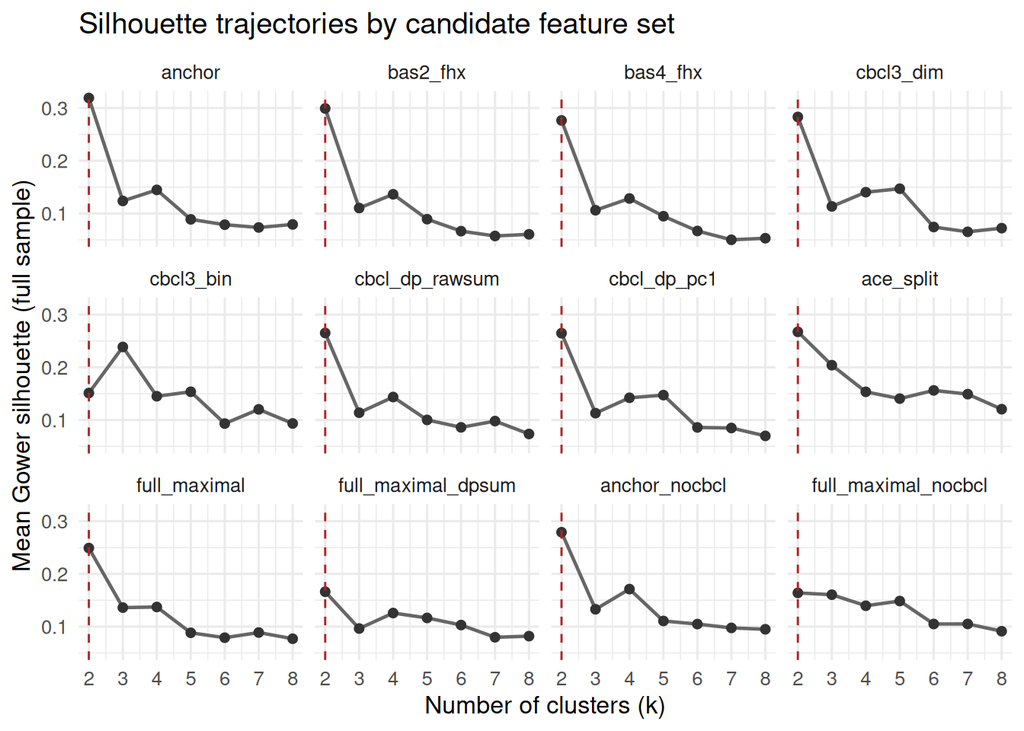

## Agreement and Stability at k = 2

Full detail: all agreement and stability metrics

| config | n_features | lambda | gower_silhouette | ari_vs_anchor | ari_vs_base | pct_reassigned_vs_base | overall_Jacc | mean_Jacc | sd_Jacc | n_higher_risk | n_lower_risk | k_opt | k2_optimal |
| --- | --- | --- | --- | --- | --- | --- | --- | --- | --- | --- | --- | --- | --- |
| anchor | 17 | 3.337 | 0.319 | 1.000 | 0.927 | 1.427 | 0.970 | 0.970 | 0.027 | 1369 | 7671 | 2 | TRUE |
| bas2_fhx | 21 | 4.526 | 0.299 | 0.927 | 1.000 | 0.000 | 0.975 | 0.975 | 0.032 | 1416 | 7624 | 2 | TRUE |
| bas4_fhx | 23 | 4.526 | 0.276 | 0.912 | 0.976 | 0.476 | 0.974 | 0.974 | 0.040 | 1433 | 7607 | 2 | TRUE |
| cbcl3_dim | 20 | 4.526 | 0.283 | 0.764 | 0.817 | 3.838 | 0.975 | 0.975 | 0.016 | 1627 | 7413 | 2 | TRUE |
| cbcl3_bin | 18 | 5.300 | 0.151 | 0.142 | 0.153 | 28.684 | 0.413 | 0.413 | 0.050 | 3303 | 5737 | 3 | FALSE |
| cbcl_dp_rawsum | 18 | 4.526 | 0.265 | 0.518 | 0.562 | 10.575 | 0.931 | 0.931 | 0.105 | 2084 | 6956 | 2 | TRUE |
| cbcl_dp_pc1 | 18 | 4.526 | 0.265 | 0.519 | 0.562 | 10.575 | 0.892 | 0.892 | 0.129 | 2088 | 6952 | 2 | TRUE |
| ace_split | 24 | 4.923 | 0.267 | 0.677 | 0.705 | 6.648 | 0.900 | 0.900 | 0.085 | 1897 | 7143 | 2 | TRUE |
| full_maximal | 26 | 4.923 | 0.249 | 0.670 | 0.698 | 6.814 | 0.898 | 0.898 | 0.089 | 1904 | 7136 | 2 | TRUE |
| full_maximal_dpsum | 23 | 4.923 | 0.166 | 0.155 | 0.164 | 28.761 | 0.845 | 0.845 | 0.181 | 3604 | 5436 | 2 | TRUE |
| anchor_nocbcl | 13 | 3.337 | 0.279 | 0.420 | 0.454 | 13.650 | 0.746 | 0.746 | 0.173 | 2084 | 6956 | 2 | TRUE |
| full_maximal_nocbcl | 22 | 4.923 | 0.164 | 0.107 | 0.114 | 32.113 | 0.960 | 0.960 | 0.016 | 3697 | 5343 | 2 | TRUE |

## Decision Aid

Separation of newly introduced features, under each configuration’s own cluster labels

| config | variable | metric | estimate |
| --- | --- | --- | --- |
| bas2_fhx | mh_y_bisbas__bas__rr_sum__v01 | d | 0.226 |
| bas2_fhx | mh_y_bisbas__bas__dr_sum | d | 0.334 |
| bas2_fhx | family_history_psychosis | OR | 4.019 |
| bas2_fhx | family_history_hospitalization | OR | 3.704 |
| bas4_fhx | mh_y_bisbas__bis_sum__v01 | d | 0.249 |
| bas4_fhx | mh_y_bisbas__bas__fs_sum | d | 0.309 |
| cbcl3_dim | mh_p_cbcl__synd__anxdep_tscore | d | 1.578 |
| cbcl3_bin | cbcl_dysregulation_binary | OR | 13.142 |
| cbcl_dp_rawsum | cbcl_dp_raw_sum | d | 1.564 |
| cbcl_dp_pc1 | cbcl_dp_pc1 | d | 1.553 |
| ace_split | ACE_index_reduced | d | 0.882 |
| ace_split | abuse_physical | OR | 2.850 |
| ace_split | abuse_sexual | OR | 3.026 |
| ace_split | abuse_emotional | OR | 5.561 |
| full_maximal | mh_y_bisbas__bis_sum__v01 | d | 0.269 |
| full_maximal | mh_y_bisbas__bas__fs_sum | d | 0.344 |
| full_maximal | ACE_index_reduced | d | 0.879 |
| full_maximal | abuse_physical | OR | 3.231 |
| full_maximal | abuse_sexual | OR | 3.193 |
| full_maximal | abuse_emotional | OR | 5.585 |
| full_maximal_dpsum | mh_y_bisbas__bis_sum__v01 | d | 0.494 |
| full_maximal_dpsum | mh_y_bisbas__bas__fs_sum | d | 0.741 |
| full_maximal_dpsum | ACE_index_reduced | d | 0.554 |
| full_maximal_dpsum | abuse_physical | OR | 2.832 |
| full_maximal_dpsum | abuse_sexual | OR | 2.022 |
| full_maximal_dpsum | abuse_emotional | OR | 16.699 |
| full_maximal_dpsum | cbcl_dp_raw_sum | d | 0.913 |

DECISION AID: what each candidate change does, relative to the base configuration (bas2_fhx)

| Config | What varies | N feat | k opt | k=2 best? | ARI vs base | % moved vs base | Silhouette | D sil vs base | Mean Jaccard | Higher-risk n | New feature separation |
| --- | --- | --- | --- | --- | --- | --- | --- | --- | --- | --- | --- |
| anchor | Published 17 features (validity check) | 17 | 2 | TRUE | 0.927 | 1.427 | 0.319 | 0.020 | 0.970 | 1369 | none added |
| bas2_fhx | BASE: + BAS RR & Drive, + FHx psychosis & hospitalization | 21 | 2 | TRUE | 1.000 | 0.000 | 0.299 | 0.000 | 0.975 | 1416 | d=0.23; d=0.33; OR=4.02; OR=3.70 |
| bas4_fhx | BASE + BIS & BAS Fun Seeking | 23 | 2 | TRUE | 0.976 | 0.476 | 0.276 | -0.023 | 0.974 | 1433 | d=0.25; d=0.31 |
| cbcl3_dim | BASE, DSM-5 dep+anx swapped for Anxious/Depressed syndrome | 20 | 2 | TRUE | 0.817 | 3.838 | 0.283 | -0.016 | 0.975 | 1627 | d=1.58 |
| cbcl3_bin | BASE, 4 CBCL scales replaced by binary DP (all T >= 65) | 18 | 3 | FALSE | 0.153 | 28.684 | 0.151 | -0.148 | 0.413 | 3303 | OR=13.14 |
| cbcl_dp_rawsum | BASE, 4 CBCL scales replaced by DP raw sum (anxdep + attn + aggr) | 18 | 2 | TRUE | 0.562 | 10.575 | 0.265 | -0.034 | 0.931 | 2084 | d=1.56 |
| cbcl_dp_pc1 | BASE, 4 CBCL scales replaced by DP PC1 (scaled PCA of 3 raw sums) | 18 | 2 | TRUE | 0.562 | 10.575 | 0.265 | -0.034 | 0.892 | 2088 | d=1.55 |
| ace_split | BASE, ACE partitioned into 3 abuse binaries + reduced sum | 24 | 2 | TRUE | 0.705 | 6.648 | 0.267 | -0.032 | 0.900 | 1897 | d=0.88; OR=2.85; OR=3.03; OR=5.56 |
| full_maximal | All accepted additions combined, CBCL held as-is | 26 | 2 | TRUE | 0.698 | 6.814 | 0.249 | -0.050 | 0.898 | 1904 | d=0.27; d=0.34; d=0.88; OR=3.23; OR=3.19; OR=5.59 |
| full_maximal_dpsum | MAXIMAL, 4 CBCL scales replaced by DP raw sum | 23 | 2 | TRUE | 0.164 | 28.761 | 0.166 | -0.133 | 0.845 | 3604 | d=0.49; d=0.74; d=0.55; OR=2.83; OR=2.02; OR=16.70; d=0.91 |
| anchor_nocbcl | ANCHOR with all 4 CBCL scales REMOVED | 13 | 2 | TRUE | 0.454 | 13.650 | 0.279 | -0.020 | 0.746 | 2084 | none added |
| full_maximal_nocbcl | MAXIMAL with all 4 CBCL scales REMOVED | 22 | 2 | TRUE | 0.114 | 32.113 | 0.164 | -0.135 | 0.960 | 3697 | none added |

```
---- Summary ----
```

```
anchor: 17 features | k_opt=2 | ARI vs base=0.927 | 1.43% moved | silhouette=0.319 | Jaccard=0.97 | clusters 1369/7671
bas2_fhx: 21 features | k_opt=2 | ARI vs base=1 | 0% moved | silhouette=0.299 | Jaccard=0.975 | clusters 1416/7624
bas4_fhx: 23 features | k_opt=2 | ARI vs base=0.976 | 0.48% moved | silhouette=0.276 | Jaccard=0.974 | clusters 1433/7607
cbcl3_dim: 20 features | k_opt=2 | ARI vs base=0.817 | 3.84% moved | silhouette=0.283 | Jaccard=0.975 | clusters 1627/7413
cbcl3_bin: 18 features | k_opt=3 | ARI vs base=0.153 | 28.68% moved | silhouette=0.151 | Jaccard=0.413 | clusters 3303/5737
cbcl_dp_rawsum: 18 features | k_opt=2 | ARI vs base=0.562 | 10.58% moved | silhouette=0.265 | Jaccard=0.931 | clusters 2084/6956
cbcl_dp_pc1: 18 features | k_opt=2 | ARI vs base=0.562 | 10.58% moved | silhouette=0.265 | Jaccard=0.892 | clusters 2088/6952
ace_split: 24 features | k_opt=2 | ARI vs base=0.705 | 6.65% moved | silhouette=0.267 | Jaccard=0.9 | clusters 1897/7143
full_maximal: 26 features | k_opt=2 | ARI vs base=0.698 | 6.81% moved | silhouette=0.249 | Jaccard=0.898 | clusters 1904/7136
full_maximal_dpsum: 23 features | k_opt=2 | ARI vs base=0.164 | 28.76% moved | silhouette=0.166 | Jaccard=0.845 | clusters 3604/5436
anchor_nocbcl: 13 features | k_opt=2 | ARI vs base=0.454 | 13.65% moved | silhouette=0.279 | Jaccard=0.746 | clusters 2084/6956
full_maximal_nocbcl: 22 features | k_opt=2 | ARI vs base=0.114 | 32.11% moved | silhouette=0.164 | Jaccard=0.96 | clusters 3697/5343
```

## Feature Separation Profiles

For each selected configuration, every feature in that configuration is ranked by how strongly it separates the two clusters, under that configuration’s own labels. Odds ratios are converted to a Cohen’s d equivalent via `effectsize::oddsratio_to_d()` so numeric and binary features can be ranked on a common scale.

Feature separation profile: bas2_fhx (BASE: + BAS RR & Drive, + FHx psychosis & hospitalization)

| rank | variable | metric | estimate | d_equivalent |
| --- | --- | --- | --- | --- |
| 1 | mh_p_cbcl__synd__aggr_tscore | d | 2.309 | 2.309 |
| 2 | mh_p_cbcl__dsm__dep_tscore | d | 2.304 | 2.304 |
| 3 | mh_p_cbcl__synd__attn_tscore | d | 2.143 | 2.143 |
| 4 | mh_p_gbi_sum | d | 1.950 | 1.950 |
| 5 | mh_p_cbcl__dsm__anx_tscore | d | 1.889 | 1.889 |
| 6 | sds_total | d | 1.633 | 1.633 |
| 7 | bullying | OR | 6.326 | 1.017 |
| 8 | family_history_depression | OR | 5.341 | 0.924 |
| 9 | ACE_index_sum_score | d | 0.836 | 0.836 |
| 10 | family_history_psychosis | OR | 4.019 | 0.767 |
| 11 | family_history_mania | OR | 3.844 | 0.742 |
| 12 | family_history_hospitalization | OR | 3.704 | 0.722 |
| 13 | fc_p_nsc__ns_mean | d | -0.470 | -0.470 |
| 14 | mh_y_upps__nurg_sum | d | 0.466 | 0.466 |
| 15 | mh_y_upps__purg_sum | d | 0.443 | 0.443 |
| 16 | le_l_coi__addr1__coi__total__national_zscore | d | -0.407 | -0.407 |
| 17 | nc_y_nihtb__lswmt__uncor_score | d | -0.400 | -0.400 |
| 18 | mh_y_bisbas__bas__dr_sum | d | 0.334 | 0.334 |
| 19 | nc_y_nihtb__flnkr__uncor_score | d | -0.287 | -0.287 |
| 20 | nc_y_nihtb__pttcp__uncor_score | d | -0.238 | -0.238 |
| 21 | mh_y_bisbas__bas__rr_sum__v01 | d | 0.226 | 0.226 |

Feature separation profile: cbcl_dp_rawsum (BASE, 4 CBCL scales replaced by DP raw sum (anxdep + attn + aggr))

| rank | variable | metric | estimate | d_equivalent |
| --- | --- | --- | --- | --- |
| 1 | cbcl_dp_raw_sum | d | 1.564 | 1.564 |
| 2 | bullying | OR | 11.144 | 1.329 |
| 3 | mh_p_gbi_sum | d | 1.254 | 1.254 |
| 4 | family_history_depression | OR | 8.761 | 1.197 |
| 5 | sds_total | d | 1.146 | 1.146 |
| 6 | ACE_index_sum_score | d | 1.017 | 1.017 |
| 7 | family_history_psychosis | OR | 4.978 | 0.885 |
| 8 | family_history_mania | OR | 4.483 | 0.827 |
| 9 | family_history_hospitalization | OR | 4.453 | 0.823 |
| 10 | fc_p_nsc__ns_mean | d | -0.670 | -0.670 |
| 11 | le_l_coi__addr1__coi__total__national_zscore | d | -0.649 | -0.649 |
| 12 | mh_y_upps__purg_sum | d | 0.613 | 0.613 |
| 13 | nc_y_nihtb__lswmt__uncor_score | d | -0.549 | -0.549 |
| 14 | mh_y_upps__nurg_sum | d | 0.547 | 0.547 |
| 15 | mh_y_bisbas__bas__dr_sum | d | 0.472 | 0.472 |
| 16 | nc_y_nihtb__flnkr__uncor_score | d | -0.388 | -0.388 |
| 17 | nc_y_nihtb__pttcp__uncor_score | d | -0.356 | -0.356 |
| 18 | mh_y_bisbas__bas__rr_sum__v01 | d | 0.327 | 0.327 |

Feature separation profile: full_maximal (All accepted additions combined, CBCL held as-is)

| rank | variable | metric | estimate | d_equivalent |
| --- | --- | --- | --- | --- |
| 1 | mh_p_cbcl__dsm__dep_tscore | d | 1.760 | 1.760 |
| 2 | mh_p_cbcl__synd__aggr_tscore | d | 1.750 | 1.750 |
| 3 | mh_p_cbcl__synd__attn_tscore | d | 1.645 | 1.645 |
| 4 | mh_p_gbi_sum | d | 1.447 | 1.447 |
| 5 | mh_p_cbcl__dsm__anx_tscore | d | 1.401 | 1.401 |
| 6 | sds_total | d | 1.377 | 1.377 |
| 7 | bullying | OR | 6.973 | 1.071 |
| 8 | family_history_depression | OR | 6.106 | 0.998 |
| 9 | abuse_emotional | OR | 5.585 | 0.948 |
| 10 | ACE_index_reduced | d | 0.879 | 0.879 |
| 11 | family_history_psychosis | OR | 4.297 | 0.804 |
| 12 | family_history_mania | OR | 4.030 | 0.768 |
| 13 | family_history_hospitalization | OR | 3.776 | 0.733 |
| 14 | abuse_physical | OR | 3.231 | 0.647 |
| 15 | abuse_sexual | OR | 3.193 | 0.640 |
| 16 | mh_y_upps__nurg_sum | d | 0.522 | 0.522 |
| 17 | mh_y_upps__purg_sum | d | 0.521 | 0.521 |
| 18 | fc_p_nsc__ns_mean | d | -0.516 | -0.516 |
| 19 | le_l_coi__addr1__coi__total__national_zscore | d | -0.456 | -0.456 |
| 20 | nc_y_nihtb__lswmt__uncor_score | d | -0.422 | -0.422 |
| 21 | mh_y_bisbas__bas__dr_sum | d | 0.407 | 0.407 |
| 22 | mh_y_bisbas__bas__fs_sum | d | 0.344 | 0.344 |
| 23 | nc_y_nihtb__flnkr__uncor_score | d | -0.296 | -0.296 |
| 24 | mh_y_bisbas__bas__rr_sum__v01 | d | 0.269 | 0.269 |
| 25 | mh_y_bisbas__bis_sum__v01 | d | 0.269 | 0.269 |
| 26 | nc_y_nihtb__pttcp__uncor_score | d | -0.267 | -0.267 |

Feature separation profile: full_maximal_dpsum (MAXIMAL, 4 CBCL scales replaced by DP raw sum)

| rank | variable | metric | estimate | d_equivalent |
| --- | --- | --- | --- | --- |
| 1 | abuse_emotional | OR | 16.699 | 1.552 |
| 2 | cbcl_dp_raw_sum | d | 0.913 | 0.913 |
| 3 | mh_y_upps__purg_sum | d | 0.842 | 0.842 |
| 4 | mh_y_bisbas__bas__dr_sum | d | 0.785 | 0.785 |
| 5 | mh_y_upps__nurg_sum | d | 0.754 | 0.754 |
| 6 | mh_p_gbi_sum | d | 0.742 | 0.742 |
| 7 | mh_y_bisbas__bas__fs_sum | d | 0.741 | 0.741 |
| 8 | sds_total | d | 0.708 | 0.708 |
| 9 | le_l_coi__addr1__coi__total__national_zscore | d | -0.658 | -0.658 |
| 10 | mh_y_bisbas__bas__rr_sum__v01 | d | 0.615 | 0.615 |
| 11 | fc_p_nsc__ns_mean | d | -0.575 | -0.575 |
| 12 | abuse_physical | OR | 2.832 | 0.574 |
| 13 | family_history_psychosis | OR | 2.827 | 0.573 |
| 14 | ACE_index_reduced | d | 0.554 | 0.554 |
| 15 | nc_y_nihtb__lswmt__uncor_score | d | -0.513 | -0.513 |
| 16 | family_history_mania | OR | 2.517 | 0.509 |
| 17 | mh_y_bisbas__bis_sum__v01 | d | 0.494 | 0.494 |
| 18 | bullying | OR | 2.414 | 0.486 |
| 19 | family_history_hospitalization | OR | 2.226 | 0.441 |
| 20 | abuse_sexual | OR | 2.022 | 0.388 |
| 21 | family_history_depression | OR | 1.922 | 0.360 |
| 22 | nc_y_nihtb__pttcp__uncor_score | d | -0.359 | -0.359 |
| 23 | nc_y_nihtb__flnkr__uncor_score | d | -0.355 | -0.355 |

Feature separation profile: anchor_nocbcl (ANCHOR with all 4 CBCL scales REMOVED)

| rank | variable | metric | estimate | d_equivalent |
| --- | --- | --- | --- | --- |
| 1 | bullying | OR | 9.507 | 1.242 |
| 2 | mh_p_gbi_sum | d | 1.158 | 1.158 |
| 3 | family_history_depression | OR | 7.937 | 1.142 |
| 4 | ACE_index_sum_score | d | 1.084 | 1.084 |
| 5 | sds_total | d | 1.054 | 1.054 |
| 6 | le_l_coi__addr1__coi__total__national_zscore | d | -0.883 | -0.883 |
| 7 | fc_p_nsc__ns_mean | d | -0.868 | -0.868 |
| 8 | family_history_mania | OR | 4.612 | 0.843 |
| 9 | mh_y_upps__purg_sum | d | 0.726 | 0.726 |
| 10 | nc_y_nihtb__lswmt__uncor_score | d | -0.618 | -0.618 |
| 11 | mh_y_upps__nurg_sum | d | 0.567 | 0.567 |
| 12 | nc_y_nihtb__flnkr__uncor_score | d | -0.489 | -0.489 |
| 13 | nc_y_nihtb__pttcp__uncor_score | d | -0.444 | -0.444 |

Feature separation profile: full_maximal_nocbcl (MAXIMAL with all 4 CBCL scales REMOVED)

| rank | variable | metric | estimate | d_equivalent |
| --- | --- | --- | --- | --- |
| 1 | abuse_emotional | OR | 17.685 | 1.584 |
| 2 | mh_y_upps__purg_sum | d | 0.870 | 0.870 |
| 3 | mh_y_bisbas__bas__dr_sum | d | 0.855 | 0.855 |
| 4 | mh_y_bisbas__bas__fs_sum | d | 0.809 | 0.809 |
| 5 | mh_y_upps__nurg_sum | d | 0.766 | 0.766 |
| 6 | le_l_coi__addr1__coi__total__national_zscore | d | -0.689 | -0.689 |
| 7 | mh_y_bisbas__bas__rr_sum__v01 | d | 0.680 | 0.680 |
| 8 | mh_p_gbi_sum | d | 0.615 | 0.615 |
| 9 | sds_total | d | 0.567 | 0.567 |
| 10 | fc_p_nsc__ns_mean | d | -0.561 | -0.561 |
| 11 | mh_y_bisbas__bis_sum__v01 | d | 0.534 | 0.534 |
| 12 | abuse_physical | OR | 2.530 | 0.512 |
| 13 | nc_y_nihtb__lswmt__uncor_score | d | -0.512 | -0.512 |
| 14 | ACE_index_reduced | d | 0.503 | 0.503 |
| 15 | family_history_psychosis | OR | 2.350 | 0.471 |
| 16 | family_history_mania | OR | 2.315 | 0.463 |
| 17 | bullying | OR | 2.267 | 0.451 |
| 18 | family_history_hospitalization | OR | 1.966 | 0.373 |
| 19 | nc_y_nihtb__pttcp__uncor_score | d | -0.373 | -0.373 |
| 20 | nc_y_nihtb__flnkr__uncor_score | d | -0.361 | -0.361 |
| 21 | family_history_depression | OR | 1.655 | 0.278 |
| 22 | abuse_sexual | OR | 1.627 | 0.268 |

[figure not shown]

## Descriptives for the Reviewer Response

Computed under the full_maximal configuration, with labels aligned so the higher-risk profile is always listed first.

Numeric candidate features by cluster (SDSC subscales descriptive only, not clustered)

| variable | Higher-risk | Lower-risk | effect | estimate | ci_low | ci_high |
| --- | --- | --- | --- | --- | --- | --- |
| mh_y_bisbas__bas__rr_sum__v01 | 9.32 ± 2.47 | 8.65 ± 2.46 | Cohen’s d | 0.269 | 0.218 | 0.320 |
| mh_y_bisbas__bas__dr_sum | 5.04 ± 3.27 | 3.83 ± 2.91 | Cohen’s d | 0.407 | 0.356 | 0.458 |
| mh_y_bisbas__bis_sum__v01 | 6.08 ± 3.00 | 5.33 ± 2.74 | Cohen’s d | 0.269 | 0.218 | 0.319 |
| mh_y_bisbas__bas__fs_sum | 6.41 ± 2.80 | 5.51 ± 2.54 | Cohen’s d | 0.344 | 0.293 | 0.395 |
| cbcl_dp_raw_sum | 19.80 ± 10.67 | 5.34 ± 4.96 | Cohen’s d | 2.196 | 2.136 | 2.255 |
| cbcl_dp_pc1 | 1.86 ± 1.73 | -0.50 ± 0.82 | Cohen’s d | 2.192 | 2.132 | 2.251 |
| mh_p_cbcl__synd__anxdep_tscore | 59.00 ± 8.37 | 51.80 ± 3.62 | Cohen’s d | 1.436 | 1.381 | 1.491 |
| mh_p_cbcl__dsm__dep_tscore | 59.71 ± 7.66 | 51.75 ± 3.21 | Cohen’s d | 1.760 | 1.703 | 1.816 |
| mh_p_cbcl__dsm__anx_tscore | 58.97 ± 8.90 | 51.79 ± 3.49 | Cohen’s d | 1.401 | 1.346 | 1.455 |
| mh_p_cbcl__synd__attn_tscore | 60.05 ± 8.51 | 51.96 ± 3.37 | Cohen’s d | 1.645 | 1.589 | 1.700 |
| mh_p_cbcl__synd__aggr_tscore | 58.53 ± 8.02 | 51.05 ± 2.44 | Cohen’s d | 1.750 | 1.694 | 1.807 |
| ACE_index_sum_score | 2.83 ± 1.34 | 1.71 ± 1.25 | Cohen’s d | 0.885 | 0.833 | 0.937 |
| ACE_index_reduced | 2.79 ± 1.30 | 1.70 ± 1.23 | Cohen’s d | 0.879 | 0.827 | 0.932 |
| sds_total | 43.90 ± 10.73 | 34.26 ± 5.60 | Cohen’s d | 1.377 | 1.323 | 1.432 |
| ph_p_sds__dims_sum | 14.58 ± 4.69 | 10.86 ± 2.88 | Cohen’s d | 1.111 | 1.058 | 1.164 |
| ph_p_sds__sbd_sum | 4.17 ± 1.60 | 3.62 ± 1.05 | Cohen’s d | 0.461 | 0.410 | 0.512 |
| ph_p_sds__da_sum | 3.83 ± 1.38 | 3.33 ± 0.70 | Cohen’s d | 0.559 | 0.508 | 0.610 |
| ph_p_sds__swtd_sum | 9.73 ± 3.47 | 7.74 ± 2.11 | Cohen’s d | 0.811 | 0.759 | 0.863 |
| ph_p_sds__does_sum | 8.67 ± 3.35 | 6.42 ± 1.75 | Cohen’s d | 1.030 | 0.977 | 1.083 |
| ph_p_sds__hyphy_sum | 2.92 ± 1.75 | 2.29 ± 0.91 | Cohen’s d | 0.557 | 0.505 | 0.608 |

Binary candidate features by cluster (NA odds ratio indicates an empty cell)

| variable | Higher-risk | Lower-risk | effect | estimate | ci_low | ci_high |
| --- | --- | --- | --- | --- | --- | --- |
| family_history_psychosis | 98 (5.1%) | 89 (1.2%) | Odds ratio | 4.297 | 3.210 | 5.751 |
| family_history_hospitalization | 380 (20.0%) | 442 (6.2%) | Odds ratio | 3.776 | 3.257 | 4.378 |
| abuse_physical | 29 (1.5%) | 34 (0.5%) | Odds ratio | 3.231 | 1.963 | 5.316 |
| abuse_sexual | 32 (1.7%) | 38 (0.5%) | Odds ratio | 3.193 | 1.990 | 5.124 |
| abuse_emotional | 1427 (74.9%) | 2489 (34.9%) | Odds ratio | 5.585 | 4.981 | 6.263 |
| cbcl_dysregulation_binary | 125 (6.6%) | 0 (0.0%) | Odds ratio | NA | NA | NA |

**How to read this run:**

- Compare `cbcl_dp_rawsum` and `cbcl_dp_pc1` against `cbcl3_bin`. All three replace four CBCL features with one. If the two continuous versions hold *k* = 2 with stability near the base while the binary does not, the `cbcl3_bin` collapse was caused by dichotomization rather than by feature reduction. If the continuous versions also degrade, feature count is doing some of the work.
- Compare `cbcl_dp_rawsum` and `cbcl_dp_pc1` against each other. If their raw sum to PC1 correlation is above roughly 0.97, expect near-identical partitions and treat them as one option.
- The **Feature Separation Profiles** for the two DP configurations show whether a single DP variable still dominates the geometry the way the four separate scales do.
- Bootstrap replicates remain at 25; rerun the chosen configuration at `n_boot = 1000` before reporting externally.